# Lesson 09: Statistical Inference Hypothesis Testing for Single Populations

11 August, 2018

# Questions

Variable Names: + 1. Type = Type of hotdog (beef, meat, or poultry) + 2. Calories = Calories per hot dog + 3. Sodium = Milligrams of sodium per hot dog

## 1.) Hotdog Calories Mean

Use hot_dogs.csv data and hypothesis tests to determine which type of hot dog has average calories less than 140 with 95% confidence. Present boxplots of calories by type of hot dog.

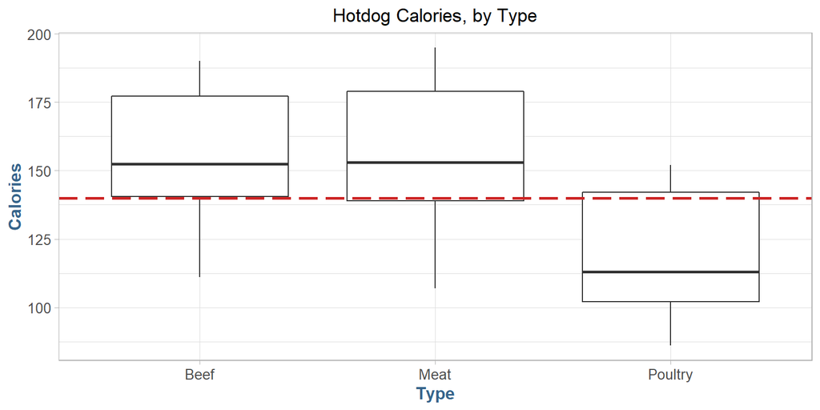

```r
test.mu <- 140

ggplot(hotdogs, aes(x = Type, y = Calories)) +
    geom_boxplot() +
    geom_abline( slope = 0, intercept = test.mu, lwd = 1, color = "firebrick3", linetype = 11) +
    labs(title = "Hotdog Calories, by Type")
```

```r
test.cal <- hotdogs[, .(Calories, Type)][, lapply(.SD, FUN = function(x) {
  t.test(Calories, mu = test.mu, alternative = "less")$conf.int[2] < test.mu
}), by = list(Type)]

pretty_kable(test.cal, title = "T-test for Calories < 140, by type")
```

T-test for Calories < 140, by type

| Type | Calories |
| --- | --- |
| Beef | FALSE |
| Meat | FALSE |
| Poultry | TRUE |

## 2.) Hotdog Sodium Mean

Using hot_dogs.csv data and hypothesis tests at the 95% confidence level, determine which type of hot dog has an average Sodium level different from 425 milligrams.

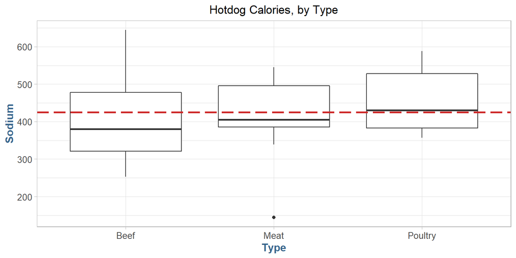

```r
test.mu <- 425

ggplot(hotdogs, aes(x = Type, y = Sodium)) +
   geom_boxplot() +
    geom_abline(slope = 0, intercept = test.mu, lwd = 1, color = "firebrick3", linetype = 11) +
    labs(title = "Hotdog Calories, by Type")
```

```r
test.cal <- hotdogs[, .(Sodium, Type)][, lapply(.SD, FUN = function(x) {
  t.test(Sodium, mu = test.mu, alternative = "two.sided", var.equal = T)$conf.int[2] < test.mu
}), by = list(Type)]

pretty_kable(test.cal, title = "T-test for Sodium == 425, by type")
```

T-test for Sodium == 425, by type

| Type | Sodium |
| --- | --- |
| Beef | FALSE |
| Meat | FALSE |
| Poultry | FALSE |

## 3.) Hotdog Sodium Variance

Using hot_dogs.csv data and hypothesis tests, determine if the variance in Sodium values for beef hot dogs is different from 6000 with 95% confidence.

```r
var.conf.int = function(x, conf.level = 0.95) {
  df <- length(x) - 1
  chilower <- qchisq((1 - conf.level) / 2, df, lower.tail = TRUE)
  chiupper <- qchisq((1 - conf.level) / 2, df, lower.tail = FALSE)
  v <- var(x)
  data.frame( Lower = df * v / chiupper, Upper = df * v / chilower)
}

sodium.var <- hotdogs[, .(Sodium, Type)][, sapply(.SD, var.conf.int), by = Type][,
   .(Type, Lower = V1, Upper = V2)]

sodium.var[ Type == "beef" & (6000 < Lower) || (6000 > Upper)]
```

| Type | Lower | Upper |
| --- | --- | --- |

## 4.) Mean Hypothesis Test

Assume a random sample of size 100 is drawn from a normal distribution for which the mean and variance are unknown. Assume the sample mean is 50 and the standard deviation of the sample is 2. Test the hypothesis that the true mean is 56, and also test the hypothesis the true mean is 40. Report p-values and comment on the results.

```r
# http://www.r-tutor.com/elementary-statistics/hypothesis-testing/two-tailed-test-population-mean-unknown-variance

samp.mean <- 50 # sample mean
test.mean1 <- 56 # mean value to test
test.mean2 <- 40 # alternate mean value to test
samp.sd <- 2 # sample standard deviation

n <- 100 # sample size
t <- (samp.mean - test.mean1) / (samp.sd / sqrt(n)) # test statistic
t #[1] -30
```

```
## [1] -30
```

```r
## [1] -30
p.value <- 2 * pt(-abs(t), df = n - 1) # we use -abs(t) because pt()

p.value # [1] 1.70085e-51
```

```
## [1] 1.70085e-51
```

```r
t <- (samp.mean - test.mean2) / (samp.sd / sqrt(n)) # test statistic
t
```

```
## [1] 50
```

```r
p.value <- 2 * pt(-abs(t), df = n - 1)
p.value # [1] 4.595366e-72
```

```
## [1] 4.595366e-72
```

## 5.) Coin Flips

A coin is flipped 100 times. If it is unbiased the probability of a heads should equal the probability of a tails. At the 95% confidence level, test the null hypothesis the coin is unbiased versus the alternative that it is biased if 43 heads are obtained. Test the same hypothesis if 63 heads are obtained. Use one-sided hypothesis tests.

```r
# Looks like another binomial problem. Refer to R documentation for prop.test().
# prop.test(x, n, p = NULL,
# alternative = c("two.sided", "less", "greater"),
# conf.level = 0.95, correct = TRUE)
# x: a vector of counts of successes, a one-dimensional table with two entries, or a two-dimensional
# table (or matrix) with 2 columns, giving the counts of successes and failures, respectively.
# n: a vector of counts of trials; ignored if x is a matrix or a table.
# p: a vector of probabilities of success. The length of p must be the same as the number of groups
# specified by x, and its elements must be greater than 0 and less than 1.
# alternative: character string specifying the alternative hypothesis,
# must be one of "two.sided" (default), "greater" or "less". You can specify just the initial letter.
# conf.level: confidence level of the returned confidence interval.
# Must be a single number between 0 and 1.
# Only used when testing the null that a single proportion equals a given value, or that two proportions
# are equal; ignored otherwise.
# correct: a logical indicating whether Yates' continuity correction should be applied where possible.

prop.test(x = 43, n = 100, alternative = "less")
```

```
##
##  1-sample proportions test with continuity correction
##
## data:  43 out of 100, null probability 0.5
## X-squared = 1.69, df = 1, p-value = 0.0968
## alternative hypothesis: true p is less than 0.5
## 95 percent confidence interval:
##  0.000000 0.517194
## sample estimates:
##    p
## 0.43
```

```r
prop.test(x = 63, n = 100, alternative = "greater")
```

```
##
##  1-sample proportions test with continuity correction
##
## data:  63 out of 100, null probability 0.5
## X-squared = 6.25, df = 1, p-value = 0.00621
## alternative hypothesis: true p is greater than 0.5
## 95 percent confidence interval:
##  0.5430629 1.0000000
## sample estimates:
##    p
## 0.63
```

## 6.) Salaries

salaries.csv contains data derived from a November 8, 1993 article in Forbes titled “America’s Best Small Companies”. The file gives the CEO age and salary for 60 small business firms. Use these data to test the hypothesis at 95% confidence that at least 50% of the CEOs are 45 years old or older. Also test the hypothesis at 95% confidence that at least 50% of the CEOs earn less than $500,000 per year. Use one-sided hypothesis tests.

```r
salaries <- loadDataFile("salaries.csv")

age <- salaries$Age >= 45
count <- sum(age)
total <- length(age)
prop.test(x = count, n = total, alternative = "greater")
```

```
##
##  1-sample proportions test with continuity correction
##
## data:  count out of total, null probability 0.5
## X-squared = 22.817, df = 1, p-value = 8.911e-07
## alternative hypothesis: true p is greater than 0.5
## 95 percent confidence interval:
##  0.7121941 1.0000000
## sample estimates:
##         p
## 0.8166667
```

```r
salary <- salaries$Sal < 500
count <- sum(salary)
total <- length(salary)
prop.test(x = count, n = total, alternative = "greater")
```

```
##
##  1-sample proportions test with continuity correction
##
## data:  count out of total, null probability 0.5
## X-squared = 10.417, df = 1, p-value = 0.0006244
## alternative hypothesis: true p is greater than 0.5
## 95 percent confidence interval:
##  0.6045034 1.0000000
## sample estimates:
##         p
## 0.7166667
```